# MOFA2 Analysis of DepMap MultiAssayExperiment

Theo Killian

2025-03-26

# Introduction

The **Cancer Dependency Map (DepMap)** is a large-scale collaborative project aimed at characterizing the genetic and molecular vulnerabilities of cancer. By systematically profiling hundreds of cancer cell lines across multiple omics platforms—including gene expression, proteomics, DNA methylation, copy number alterations, mutations, and genetic perturbation screens (e.g., CRISPR)—DepMap provides a rich resource for understanding the molecular basis of cancer dependencies and identifying therapeutic targets.

To fully harness the potential of such diverse data types, **multi-omics integration** is essential. This process involves combining information from various molecular layers to obtain a holistic view of biological systems. Integration enables the identification of cross-platform relationships, reveals shared latent structures, and improves the interpretability of complex datasets.

**Multi-Omics Factor Analysis version 2 (MOFA2)** is an unsupervised machine learning framework specifically designed for the integration of multi-modal biological data. MOFA2 models the sources of variability across different omic layers by learning a set of latent factors that capture the underlying structure of the data. These factors can be used to uncover biologically meaningful patterns, perform dimensionality reduction, visualize sample relationships, and cluster samples based on shared molecular features.

In this document, we use MOFA2 to analyze a curated `MultiAssayExperiment` object derived from DepMap melanoma cell lines. By integrating multiple omics assays, we aim to uncover latent molecular programs, identify clusters of similar cell lines, and explore the biological variance captured across platforms.

*In the sections that follow, readers can expect to find:*

- **Step-by-step preprocessing and alignment** of multiple omics layers, ensuring that data from all assays are harmonized and suitable for integration.
- **Construction and training of a MOFA2 model**, capturing sources of variance across omics platforms without the use of prior labels or supervision.
- **Interpretation of latent factors**, including variance explained by each factor and feature-level contributions (weights) that highlight genes, proteins, or epigenetic features driving molecular programs.
- **Visualization of cell line relationships in latent space**, using clustering and dimensionality reduction to identify subgroups of melanoma lines with shared molecular features.
- **Evaluation of biological associations**, where latent factors are correlated with sample-level annotations such as metastatic status or other metadata, demonstrating how MOFA2 can facilitate hypothesis generation.
- **Practical guidance** on how to extract and interpret key outputs of the MOFA2 model, including factor scores, feature weights, and cluster assignments.

This document is designed for researchers interested in applying **unsupervised integrative modeling** to complex biological datasets. It balances methodological rigor with interpretable outputs, providing a template for multi-omics exploration in cancer genomics and beyond.

## Step 1: Load Data

We load the preprocessed `MultiAssayExperiment` object saved as a RDS file, which was constructed in the previous `make_depmap_melanoma_MAE.R` script.

```r
depmap_mae <- readRDS(file = paste0("./MAE/depmap_MAE_2025-03-18.rds"))

assays(depmap_mae)
```

```
#> List of length 5
#> names(5): crispr copy_number tpm_exp proteomic methylation
```

## Step 2: Prepare Data for MOFA2, Align samples across assays

This step prepares the metadata and sample annotations across the assays, which will be used at a later step in the analysis.

```r
depmap_mae <- intersectColumns(depmap_mae)

# Convert assay data into sparse matrices for efficiency
convert_to_matrix <- function(se_object) {
  assay_data <- assay(se_object)
  if (is(assay_data, "dgCMatrix")) {
    return(as.matrix(assay_data))  # Convert sparse matrices to dense matrices for MOFA2
  } else if (is.data.frame(assay_data)) {
    return(as.matrix(assay_data))  # Convert data.frame to matrix
  } else {
    return(assay_data)  # Already in matrix format
  }
}

# Extract and format the assays
mofa_data <- lapply(experiments(depmap_mae), convert_to_matrix)

# Confirm all elements are now sparse matrices
str(mofa_data)
```

```
#> List of 5
#>  $ crispr     : num [1:17916, 1:24] 0.0613 -0.0133 0.1597 0.215 -0.1003 ...
#>   ..- attr(*, "dimnames")=List of 2
#>   .. ..$ : chr [1:17916] "A1BG" "A1CF" "A2M" "A2ML1" ...
#>   .. ..$ : chr [1:24] "ACH-000899" "ACH-000014" "ACH-000219" "ACH-000304" ...
#>  $ copy_number: num [1:38590, 1:24] 1.289 1.297 0.892 1.682 0.884 ...
#>   ..- attr(*, "dimnames")=List of 2
#>   .. ..$ : chr [1:38590] "RHEB" "TIPIN" "OR4A47" "NUP133" ...
#>   .. ..$ : chr [1:24] "ACH-000899" "ACH-000014" "ACH-000219" "ACH-000304" ...
#>  $ tpm_exp    : num [1:19221, 1:24] 3.97 0 7.49 3.53 4.42 ...
#>   ..- attr(*, "dimnames")=List of 2
#>   .. ..$ : chr [1:19221] "TSPAN6" "TNMD" "DPM1" "SCYL3" ...
#>   .. ..$ : chr [1:24] "ACH-000899" "ACH-000014" "ACH-000219" "ACH-000304" ...
#>  $ proteomic  : num [1:12210, 1:24] 0.393 -0.297 0.121 -1.066 -2.65 ...
#>   ..- attr(*, "dimnames")=List of 2
#>   .. ..$ : chr [1:12210] "SLC12A2" "HOXD13" "KDM1A" "SOX1" ...
#>   .. ..$ : chr [1:24] "ACH-000899" "ACH-000014" "ACH-000219" "ACH-000304" ...
#>  $ methylation: num [1:21337, 1:24] 0.055 0.0207 0.0127 0 0 ...
#>   ..- attr(*, "dimnames")=List of 2
#>   .. ..$ : chr [1:21337] "AGBL4_1_50489626_50490626" "AJAP1_1_4714104_4715104" "ACOT7_1_6453826_6454826" "ACOT7_1_6445883_6446883" ...
#>   .. ..$ : chr [1:24] "ACH-000899" "ACH-000014" "ACH-000219" "ACH-000304" ...
```

## Step 3: Create and Train the MOFA2 Model, Create MOFA object

```r
mofa_model <- create_mofa(mofa_data)

# Define model and training options
data_opts <- get_default_data_options(mofa_model)
model_opts <- get_default_model_options(mofa_model)
train_opts <- get_default_training_options(mofa_model)

# Performance Improvements
train_opts$maxiter <- 1000                   # Increase iterations for convergence

# Train the MOFA model
mofa_model <- prepare_mofa(mofa_model,
                           data_options = data_opts,
                           model_options = model_opts,
                           training_options = train_opts)

mofa_model <- run_mofa(mofa_model, use_basilisk = TRUE)
```

[output not shown]

[output cut: 192 more lines]

[output not shown]

#### Interpreting MOFA2 Factor Weights

In MOFA2, **factor weights** quantify how strongly each feature (e.g., gene, protein, or methylation site) contributes to a given latent factor in a specific omic view. These weights are learned during model training and are analogous to loadings in principal component analysis (PCA), but tailored for multi-modal data. A high absolute weight indicates that the feature plays a major role in defining the factor’s structure, while weights close to zero suggest minimal influence. The sign of the weight (positive or negative) reflects the direction of association: features with positive weights tend to increase in samples with high factor scores, whereas features with negative weights decrease. By examining the distribution and magnitude of weights, researchers can identify key drivers of latent variability across assays, uncover coordinated biological programs, and generate hypotheses about regulatory mechanisms underlying specific molecular patterns. Visualizations such as weight plots or ranked feature lists enable further biological interpretation of the most influential features for each factor.

## Step 4: Visualize Results, Visualize variance explained by each factor

### Plot the top latent factors

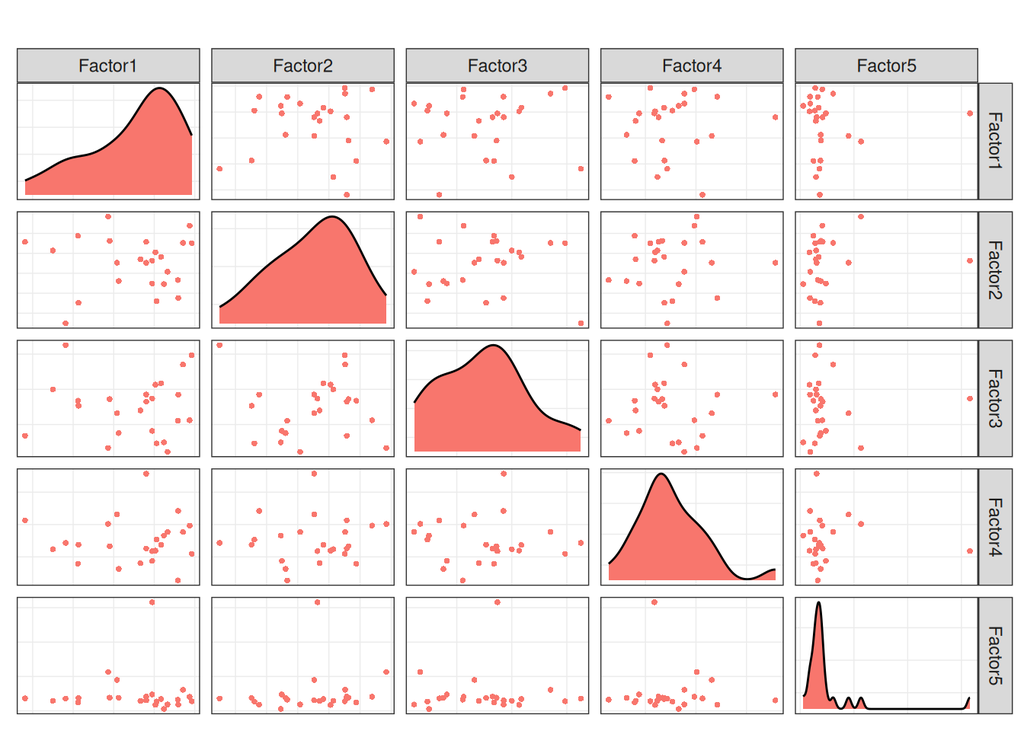

```r
plot_factors(mofa_model, factors = 1:5)
```

### Heatmap displaying the variance of latent factors between omics assays

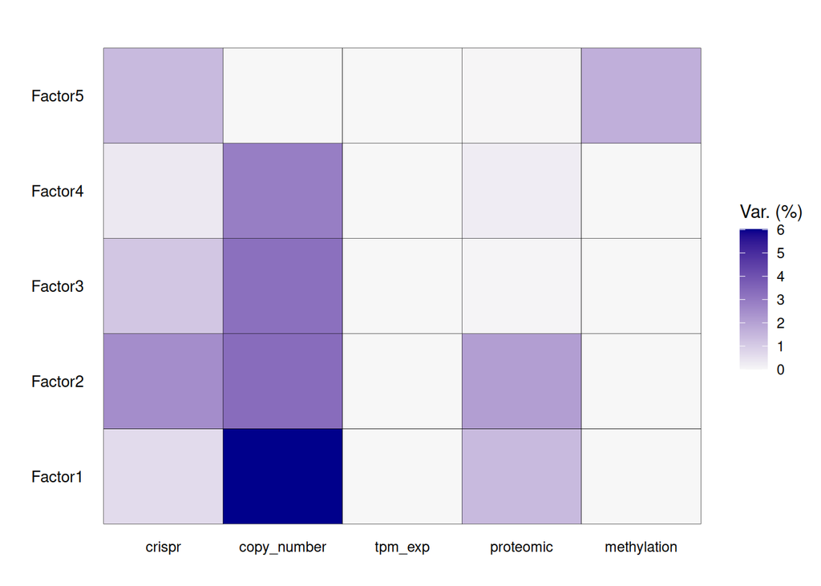

```r
plot_variance_explained(mofa_model)
```

#### Closer look at the weights in the Copy Number omics assay

The heatmap shown above appears to show that there is high variance between copy number within the first latent factor. Let’s look at these weights directly:

```r
get_weights(mofa_model, view = "copy_number") %>% as.data.frame() %>%
  dplyr::slice(1:20)
```

```
#>                     copy_number.Factor1 copy_number.Factor2 copy_number.Factor3
#> RHEB_copy_number            0.132238120         0.150444627         -0.03602386
#> TIPIN_copy_number          -0.077526256        -0.181071982          0.39061704
#> OR4A47_copy_number          0.325676173         0.153455347          1.17699969
#> NUP133_copy_number          0.324673533         0.196716204          1.00438881
#> CPNE8-AS1                   0.160648286        -0.044019740          0.08948069
#> PDIA4_copy_number           0.150305003         0.128913209         -0.04007560
#> RNU6-899P                  -0.005858609        -0.055166345          0.28789559
#> NRXN1-DT                   -0.125867352        -0.177316815         -1.64834857
#> SMIM41_copy_number          0.180430934        -0.042535439          0.21909282
#> RPS12P2                    -0.201687083         0.004732653          0.27837586
#> IGHJ2                       0.241393685        -0.058684446          0.08973384
#> SLC2A3P2                   -0.089710832        -0.734072447         -0.72287995
#> CES4A_copy_number          -0.022649031         0.365707278         -0.89387286
#> TCTE1_copy_number           0.297679245        -0.329309613         -0.06133308
#> TAX1BP1_copy_number         0.134078085         0.219087183         -0.28338248
#> RPL32P26                    0.284177393        -0.045460977          0.38066557
#> PNCK_copy_number            0.081238344         0.198547408         -0.71550101
#> CNOT10-AS1                 -0.180463314         0.097159095          0.08242860
#> OR3A2_copy_number           0.343149364         0.113587469          0.15667602
#> COL6A2_copy_number          0.530258656         0.279896766          0.10229649
#>                     copy_number.Factor4 copy_number.Factor5
#> RHEB_copy_number            -0.09807475        1.143364e-03
#> TIPIN_copy_number            0.21534161        1.530067e-04
#> OR4A47_copy_number          -0.05071431        2.387483e-04
#> NUP133_copy_number          -0.04085838       -2.053667e-04
#> CPNE8-AS1                    0.36066952        3.365359e-04
#> PDIA4_copy_number           -0.09061874        1.133397e-03
#> RNU6-899P                   -0.05465066       -8.554651e-06
#> NRXN1-DT                     0.07935402       -3.726499e-04
#> SMIM41_copy_number           0.04852384        3.162538e-04
#> RPS12P2                     -0.08528589        4.430539e-04
#> IGHJ2                       -0.40270728       -3.163569e-05
#> SLC2A3P2                     0.09430230       -1.127554e-03
#> CES4A_copy_number            0.55735314        3.948794e-04
#> TCTE1_copy_number           -0.24270688       -4.857559e-04
#> TAX1BP1_copy_number          0.02315054       -2.027883e-04
#> RPL32P26                    -0.03955153       -6.765370e-05
#> PNCK_copy_number             0.12470710       -2.337461e-05
#> CNOT10-AS1                  -0.32457277       -6.048652e-04
#> OR3A2_copy_number            0.02782761        4.429293e-04
#> COL6A2_copy_number           0.26136759       -2.081927e-04
```

#### Interpreting Positive versus Negative Weights

##### Positive Weights

A **positive weight** for a gene in a given factor means that **increased copy number** of that gene is **positively associated** with higher scores on that latent factor.

**Example:**

- `COL6A2_copy_number` has a positive weight of **0.530** on **Factor1**.
  - This suggests that samples (e.g., cell lines) with high scores on Factor1 tend to have **increased copy number of COL6A2**.

##### Negative Weights

A **negative weight** implies the opposite: **increased copy number** of the feature is associated with **lower values** on that factor.

**Example:**

- `RNU7-179P` has a weight of **-0.412** on **Factor1**.
  - So samples with high scores on Factor1 tend to have **lower copy number of RNU7-179P**, or conversely, **high copy number of RNU7-179P pushes the factor score down**.

##### Zero or Near-Zero Weights

Weights close to zero suggest that the feature has **little or no influence** on that factor.

These features contribute minimally and are typically **not interpreted** in downstream analyses.

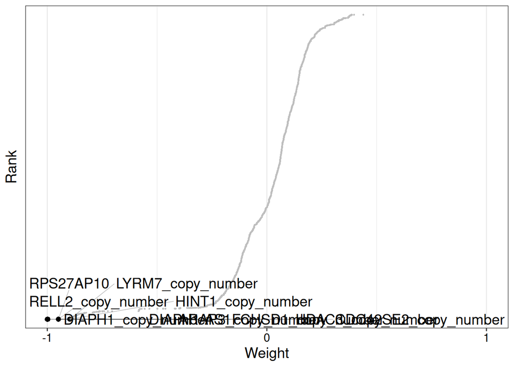

```r
plot_weights(mofa_model, view = "copy_number", factor = 1)
```

## Step 5: Cluster and Analyze the Latent Space, Extract factor scores

```r
factor_scores <- get_factors(mofa_model)[[1]]

factor_scores %>% as.data.frame() %>%
  dplyr::slice(1:20)
```

```
#>                Factor1      Factor2      Factor3      Factor4      Factor5
#> ACH-000899  0.12091170  0.102114886  0.060204469  0.027052058  0.005645978
#> ACH-000014  0.13739413  0.188638464 -0.018822391  0.046757910 -0.004469613
#> ACH-000219 -0.04196862  0.002780191 -0.008919834  0.081240587  0.020005699
#> ACH-000304  0.01582822  0.020255500 -0.004957282 -0.069429666 -0.010467137
#> ACH-000348  0.08283994 -0.042397562 -0.063761920  0.026887445 -0.015642995
#> ACH-000404  0.03018996  0.002505843  0.017659454  0.207170293 -0.009686450
#> ACH-000425  0.04486775 -0.101112433 -0.034009121 -0.062344015 -0.001121709
#> ACH-000441 -0.05999833  0.112808086  0.011177979 -0.016847247 -0.005766792
#> ACH-000550 -0.26880765  0.107424982 -0.040909179  0.062895648 -0.006781869
#> ACH-000579  0.05561894 -0.189329818 -0.051668942  0.003494623 -0.011372734
#> ACH-000580  0.04487609  0.013364837  0.011930538 -0.032116611  0.132929936
#> ACH-000614  0.03010573  0.107452169  0.007508465 -0.024114985 -0.004124950
#> ACH-000632 -0.03774168 -0.089022249 -0.037121400 -0.087175503 -0.005919473
#> ACH-000661  0.14257391  0.101119667  0.073461190 -0.040375683 -0.010976098
#> ACH-000788  0.06672321  0.032364052  0.033650242 -0.012910421 -0.007777700
#> ACH-000799 -0.06382968  0.234304279 -0.058149822  0.051870506  0.031531643
#> ACH-000805  0.10919562 -0.173945665  0.017518939  0.092082545 -0.015927050
#> ACH-000810 -0.16870247 -0.300901026  0.087764949 -0.006874647 -0.007059536
#> ACH-000827  0.05286178  0.055295568  0.031650953 -0.030782465 -0.016374301
#> ACH-000881 -0.13821186  0.137929514  0.008876387 -0.071136467 -0.012684905
```

### Perform k-means clustering

```r
set.seed(42)
kmeans_clusters <- kmeans(factor_scores, centers = 3)
```

### Visualize clusters

```r
eh <- ExperimentHub()
query(eh, "depmap")
```

```
#> ExperimentHub with 82 records
#> # snapshotDate(): 2024-10-24
#> # $dataprovider: Broad Institute
#> # $species: Homo sapiens
#> # $rdataclass: tibble
#> # additional mcols(): taxonomyid, genome, description,
#> #   coordinate_1_based, maintainer, rdatadateadded, preparerclass, tags,
#> #   rdatapath, sourceurl, sourcetype
#> # retrieve records with, e.g., 'object[["EH2260"]]'
#>
#>            title
#>   EH2260 | rnai_19Q1
#>   EH2261 | crispr_19Q1
#>   EH2262 | copyNumber_19Q1
#>   EH2263 | RPPA_19Q1
#>   EH2264 | TPM_19Q1
#>   ...      ...
#>   EH7555 | copyNumber_22Q2
#>   EH7556 | TPM_22Q2
#>   EH7557 | mutationCalls_22Q2
#>   EH7558 | metadata_22Q2
#>   EH7559 | achilles_22Q2
```

```r
eh[["EH7558"]] %>%
  dplyr::filter(grepl("melanoma", lineage_subtype) |
                  grepl("elanoma", Cellosaurus_NCIt_disease) |
                  grepl("elanoma", subtype_disease) |
                  grepl("elanoma", cell_line)) %>%
  dplyr::select(-contains("issues")) %>%
  as.data.frame() -> melanoma_metadata_22Q2

data.frame(factor_scores, Cluster = factor(kmeans_clusters$cluster)) %>%
  tibble::rownames_to_column(var = "depmap_id") %>%
  dplyr::left_join(melanoma_metadata_22Q2, by = "depmap_id") %>%
  dplyr::mutate(
    primary_or_metastasis = tidyr::replace_na(primary_or_metastasis, "unknown"),
    primary_or_metastasis = as.factor(primary_or_metastasis)) %>%
  tibble::column_to_rownames(var = "depmap_id") %>%
  as.data.frame() -> factor_df
```

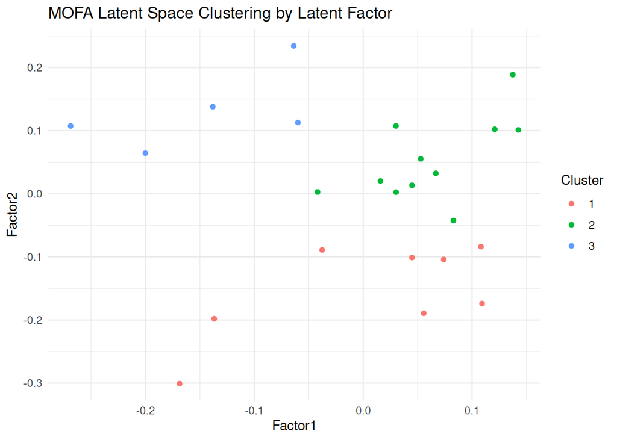

```r
ggplot(factor_df, aes(x = Factor1, y = Factor2, color = Cluster)) +
  geom_point() +
  theme_minimal() +
  labs(title = "MOFA Latent Space Clustering by Latent Factor")
```

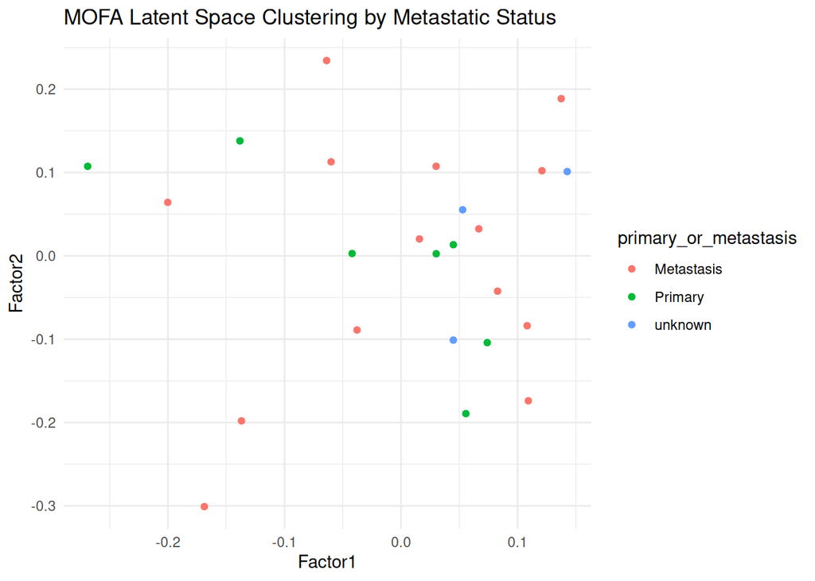

```r
ggplot(factor_df, aes(x = Factor1, y = Factor2, color = primary_or_metastasis)) +
  geom_point() +
  theme_minimal() +
  labs(title = "MOFA Latent Space Clustering by Metastatic Status")
```

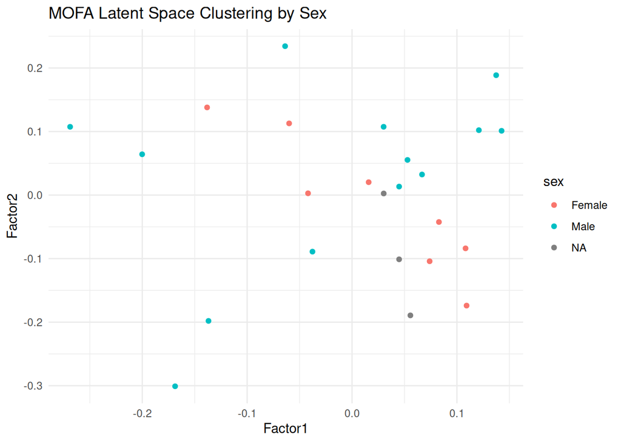

```r
ggplot(factor_df, aes(x = Factor1, y = Factor2, color = sex)) +
  geom_point() +
  theme_minimal() +
  labs(title = "MOFA Latent Space Clustering by Sex")
```

## Check Whether a Factor Separates Your Classes

After training, we retrieve the latent factor scores (sample-level) and examine whether any factor (or combination of factors) correlates with the `primary` versus `metastatic` annotations.

**Note:** *While there doesn’t appear to be a significant correlation between primary versus metastatic samples, this demonstrates how such a a correlation can be performed.*

```r
factor_scores <- get_factors(mofa_model)
# factor_scores is usually a list of matrices, one per view or combined

as.data.frame(factor_scores[[1]][, "Factor2"]) %>%
  tibble::rownames_to_column(var = "depmap_id") %>%
  dplyr::left_join(melanoma_metadata_22Q2, by = "depmap_id") %>%
  dplyr::mutate(primary_metastatic_label =  ifelse(primary_or_metastasis == "Metastasis", 1, 0),
                primary_metastatic_label = tidyr::replace_na(primary_metastatic_label, 0)) %>%
  dplyr::rename(factor_scores_1 = names(.)[2]) %>%
  as.data.frame() -> factor_metastasis

# For instance, see if Factor1 is associated with your annotation:
cor.test(factor_metastasis$factor_scores_1, as.numeric(factor_metastasis$primary_metastatic_label))
```

```
#>
#>  Pearson's product-moment correlation
#>
#> data:  factor_metastasis$factor_scores_1 and as.numeric(factor_metastasis$primary_metastatic_label)
#> t = -0.078736, df = 22, p-value = 0.938
#> alternative hypothesis: true correlation is not equal to 0
#> 95 percent confidence interval:
#>  -0.4173552  0.3892479
#> sample estimates:
#>         cor
#> -0.01678429
```

## Retrieve factor weights for that factor

Assuming that the factor scores for our factor of interest (`Factor2`) were in fact significant,

```r
# For example, for copy number
get_weights(mofa_model, view = "copy_number") %>%
  as.data.frame() %>%
  tibble::rownames_to_column(var = "feature") %>%
  dplyr::mutate(abs_val = abs(copy_number.Factor2)) %>%
  dplyr::filter(grepl("copy_number", feature)) %>%
  dplyr::arrange(desc(abs_val)) -> weights_df

weights_df %>% head(20)
```

```
#>                feature copy_number.Factor1 copy_number.Factor2
#> 1  A3GALT2_copy_number          -0.2724124          -0.9773120
#> 2  ZSCAN20_copy_number          -0.2668395          -0.9763609
#> 3     PHC2_copy_number          -0.2668395          -0.9763609
#> 4     DAB1_copy_number          -0.1021778          -0.9724606
#> 5    CSMD2_copy_number          -0.2954787          -0.9721438
#> 6    HMGB4_copy_number          -0.2968996          -0.9713075
#> 7  C1orf94_copy_number          -0.2968996          -0.9713075
#> 8     FYB2_copy_number          -0.1661764          -0.9610156
#> 9      C8A_copy_number          -0.1661764          -0.9610156
#> 10   PLPP3_copy_number          -0.1661764          -0.9610156
#> 11     C8B_copy_number          -0.1661764          -0.9610156
#> 12  PRKAA2_copy_number          -0.1661764          -0.9610156
#> 13    SCP2_copy_number          -0.2724870          -0.9519491
#> 14  SLC1A7_copy_number          -0.2661989          -0.9516731
```

[output cut: 27 more lines]

## Summary

In this analysis, we applied **MOFA2** to a multi-omics dataset derived from the **DepMap melanoma cell lines**, organized as a `MultiAssayExperiment` object. The following steps summarize the workflow:

1. **Data Loading and Preprocessing**:  
   We loaded a previously saved `MultiAssayExperiment` object containing matched multi-omic profiles from DepMap. The samples were aligned across all assays using `intersectColumns()` to ensure consistent sample identifiers.
2. **Data Formatting for MOFA2**:  
   Each assay was extracted and converted into a dense matrix format suitable for MOFA2. This step ensures compatibility across omic layers and maximizes computational efficiency.
3. **Model Creation and Training**:  
   A MOFA2 model was initialized with the prepared data. Default options were used for data, model, and training configurations, with an increased maximum number of iterations to improve convergence. The model was trained using the `run_mofa()` function with basilisk for environment management.
4. **Variance and Factor Visualization**:  
   We examined the variance explained by each latent factor to assess how much structure MOFA2 captures from each omic layer. Latent factor plots provided a 2D representation of the samples in the reduced space, and weight plots highlighted features contributing most to each factor.
5. **Clustering in Latent Space**:  
   Factor scores extracted from the trained model were used for unsupervised clustering via k-means. The resulting clusters were visualized using a scatter plot of the first two latent factors, revealing distinct groupings among the melanoma cell lines.

Overall, this analysis demonstrates how MOFA2 can be effectively applied to integrated DepMap data to identify latent patterns and uncover molecular subtypes across cancer cell lines using multi-omics integration.

6. **Analyzing Latent Space Weights** We demonstrated how to correlate and interpret MOFA2 latent space weights and connect them to annotations.